# Applied Machine Learning

In-class exercise 10-2

# Goal

Learn how to do stacking with `mlr3pipelines`.

# German Credit Data

## Description

- Data from 1973 to 1975 from a large regional bank in southern Germany classifying credits described by a set of attributes to good or bad credit risks.
- Stratified sample of 1000 credits (300 bad ones and 700 good ones).
- Customers with good credit risks perfectly complied with the conditions of the contract while customers with bad credit risks did not comply with the contract as required.
- Available in `tsk("german_credit")`.

## Data Dictionary

n = 1,000 observations of credits

- `credit_risk`: Has the credit contract been complied with (good) or not (bad)?
- `age`: Age of debtor in years
- `amount`: Credit amount in DM
- `credit_history`: History of compliance with previous or concurrent credit contracts
- `duration`: Credit duration in months
- `employment_duration`: Duration of debtor’s employment with current employer
- `foreign_worker`: Whether the debtor is a foreign worker
- `housing`: Type of housing the debtor lives in
- `installment_rate`: Credit installments as a percentage of debtor’s disposable income
- `job`: Quality of debtor’s job
- `number_credits`: Number of credits including the current one the debtor has (or had) at this bank
- `other_debtors`: Whether there is another debtor or a guarantor for the credit
- `other_installment_plans`: Installment plans from providers other than the credit-giving bank
- `people_liable`: Number of persons who financially depend on the debtor
- `personal_status_sex`: Combined information on sex and marital status
- `present_residence`: Length of time (in years) the debtor lives in the present residence
- `property`: The debtor’s most valuable property
- `purpose`: Purpose for which the credit is needed
- `savings`: Debtor’s saving
- `status`: Status of the debtor’s checking account with the bank
- `telephone`: Whether there is a telephone landline registered on the debtor’s name

# Exercises

## Exercise 1: Single- and Multilayer Stacking

So far, we have not cross-validated the level 0 predictions. Create another stacked ensemble where you use 3-fold CV to cross-validate the level 0 predictions.

So far, we have dropped the original features of the task. Create another stacked ensemble where you additionally keep the original features of the task.

**Hint 1:**

To wrap a learner within an ensemble and use its predictions, the learner_cv `PipeOp` is essential. Its `resampling.method` hyperparameter allows you to cross-validate the predictions or not. Similarly `resampling.folds` allows you to specify the number of folds if predictions should be cross-validated. To combine the level 0 output, use the featureunion `PipeOp`. To keep the original features of the task in the output of level 0, use the nop `PipeOp` along the learners. To make sure that when you pass the original features of the task to the final level 2 that you do not also pass the cross-validated predictions from level 1, use an appropriately configured select `PipeOp`. The following gallery post could be helpful: https://mlr-org.com/gallery/pipelines/2020-04-27-tuning-stacking/index.html

**Hint 2:**

```r
library(mlr3)
library(mlr3learners)
library(mlr3pipelines)
library(mlr3viz)

task = tsk("german_credit")

set.seed(2409)
resampling = rsmp("cv", folds = ...)$instantiate(task)
dt = lrn("classif.rpart")
dt$predict_type = "prob"
kknn = lrn(..., k = ...)
kknn$predict_type = "prob"
elnet = lrn(..., alpha = ..., s = ...)
elnet$predict_type = "prob"
elnet = as_learner(po(...) %>>% ...)
naive_bayes = lrn(...)
naive_bayes$predict_type = "prob"
naive_bayes = as_learner(po(...) %>>% ...)
xgboost = lrn(..., nrounds = ...)
xgboost = as_learner(po(...) %>>% ...)
xgboost$predict_type = "prob"
rf = lrn(..., num.trees = ..._
rf$predict_type = "prob"

level0 = gunion(
  list(
    po("learner_cv", learner = ..., resampling.method = ...),
    ...
  )
) %>>% po(...)
level0$plot()

level0_train_output = level0$train(task)
level0_train_output

level1 = lrn(..., id = "log_reg_out")
level1$predict_type = "prob"

ensemble = as_learner(level0 %>>% level1)
ensemble$id = "Simple Stacked Ensemble Insample"
ensemble$graph$plot()

bg = benchmark_grid(..., list(...), ...)
b = benchmark(bg)
autoplot(..., measure = ...

.
.
.
```

### Solution:

**Click me:**

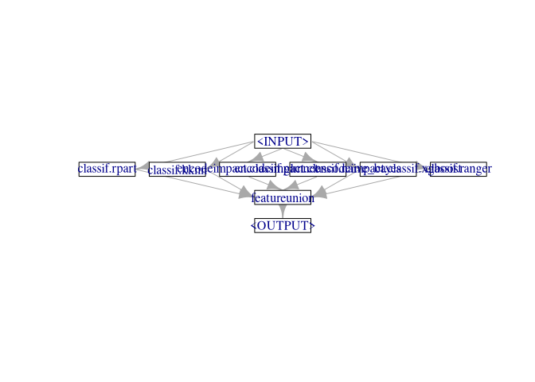

```r
library(mlr3)
library(mlr3learners)
library(mlr3pipelines)
library(mlr3viz)

task = tsk("german_credit")

set.seed(2409)
resampling = rsmp("cv", folds = 5L)$instantiate(task)
dt = lrn("classif.rpart")
dt$predict_type = "prob"
kknn = lrn("classif.kknn", k = 7L)
kknn$predict_type = "prob"
elnet = lrn("classif.glmnet", alpha = 0.5, s = 0.01)
elnet$predict_type = "prob"
elnet = as_learner(po("encodeimpact") %>>% elnet)
naive_bayes = lrn("classif.naive_bayes")
naive_bayes$predict_type = "prob"
naive_bayes = as_learner(po("encodeimpact") %>>% naive_bayes)
xgboost = lrn("classif.xgboost", nrounds = 100L)
xgboost = as_learner(po("encodeimpact") %>>% xgboost)
xgboost$predict_type = "prob"
rf = lrn("classif.ranger", num.trees = 100L)
rf$predict_type = "prob"

level0 = gunion(
  list(
    po("learner_cv", learner = dt, resampling.method = "insample"),
    po("learner_cv", learner = kknn, resampling.method = "insample"),
    po("learner_cv", learner = elnet, resampling.method = "insample"),
    po("learner_cv", learner = naive_bayes, resampling.method = "insample"),
    po("learner_cv", learner = xgboost, resampling.method = "insample"),
    po("learner_cv", learner = rf, resampling.method = "insample")
  )
) %>>% po("featureunion")
level0$plot()
```

```r
level0_train_output = level0$train(task)
level0_train_output
```

```
## $featureunion.output
## <TaskClassif:german_credit> (1000 x 13): German Credit
## * Target: credit_risk
## * Properties: twoclass
## * Features (12):
##   - dbl (12): classif.kknn.prob.bad, classif.kknn.prob.good, classif.ranger.prob.bad,
##     classif.ranger.prob.good, classif.rpart.prob.bad, classif.rpart.prob.good,
##     encodeimpact.classif.glmnet.prob.bad, encodeimpact.classif.glmnet.prob.good,
##     encodeimpact.classif.naive_bayes.prob.bad, encodeimpact.classif.naive_bayes.prob.good,
##     encodeimpact.classif.xgboost.prob.bad, encodeimpact.classif.xgboost.prob.good
```

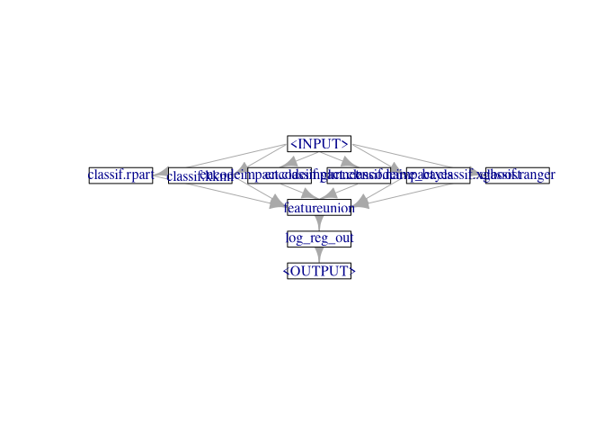

```r
# This is a task that contains the probability predictions for each class from each learner
# To also have the predicted class, we could set the `resampling.keep_response` of the learner_cv `PipeOp`

level1 = lrn("classif.log_reg", id = "log_reg_out")
level1$predict_type = "prob"

ensemble = as_learner(level0 %>>% level1)
ensemble$id = "Simple Stacked Ensemble Insample"
ensemble$graph$plot()
```

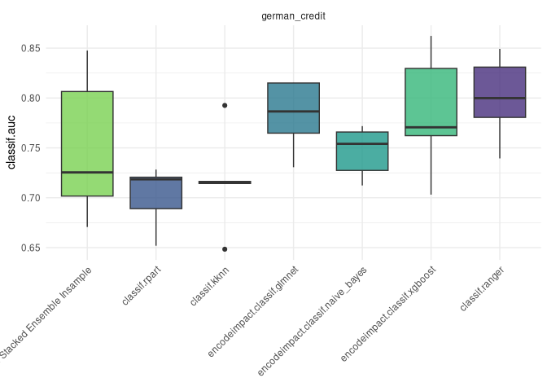

```r
bg = benchmark_grid(task, list(ensemble, dt, kknn, elnet, naive_bayes, xgboost, rf), resampling)
b = benchmark(bg)
autoplot(b, measure = msr("classif.auc"))
```

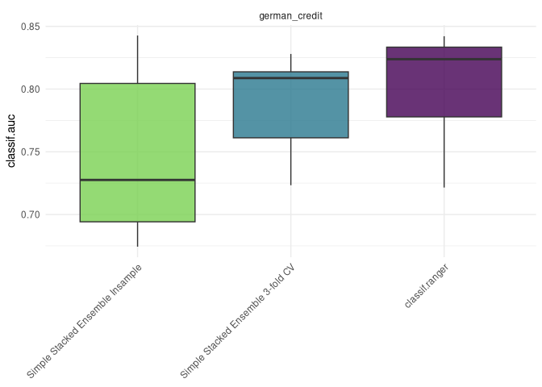

```r
level0 = gunion(
  list(
    po("learner_cv", learner = dt, resampling.method = "cv", resampling.folds = 3L),
    po("learner_cv", learner = kknn, resampling.method = "cv", resampling.folds = 3L),
    po("learner_cv", learner = elnet, resampling.method = "cv", resampling.folds = 3L),
    po("learner_cv", learner = naive_bayes, resampling.method = "cv", resampling.folds = 3L),
    po("learner_cv", learner = xgboost, resampling.method = "cv", resampling.folds = 3L),
    po("learner_cv", learner = rf, resampling.method = "cv", resampling.folds = 3L)
  )
) %>>% po("featureunion")

ensemble_cv = as_learner(level0 %>>% level1)
ensemble_cv$id = "Simple Stacked Ensemble 3-fold CV"

bg = benchmark_grid(task, list(ensemble, ensemble_cv, rf), resampling)
b = benchmark(bg)
autoplot(b, measure = msr("classif.auc"))
```

```r
level0 = gunion(
  list(
    po("learner_cv", learner = dt, resampling.method = "cv", resampling.folds = 3L),
    po("learner_cv", learner = kknn, resampling.method = "cv", resampling.folds = 3L),
    po("learner_cv", learner = elnet, resampling.method = "cv", resampling.folds = 3L),
    po("learner_cv", learner = naive_bayes, resampling.method = "cv", resampling.folds = 3L),
    po("learner_cv", learner = xgboost, resampling.method = "cv", resampling.folds = 3L),
    po("learner_cv", learner = rf, resampling.method = "cv", resampling.folds = 3L),
    po("nop")
  )
) %>>% po("featureunion")
level0_train_output = level0$train(task)[[1L]]
level0_train_output
## <TaskClassif:german_credit> (1000 x 33): German Credit
## * Target: credit_risk
## * Properties: twoclass
## * Features (32):
##   - fct (14): credit_history, employment_duration, foreign_worker, housing, job, other_debtors,
##     other_installment_plans, people_liable, personal_status_sex, property, purpose, savings, status,
##     telephone
##   - dbl (12): classif.kknn.prob.bad, classif.kknn.prob.good, classif.ranger.prob.bad,
##     classif.ranger.prob.good, classif.rpart.prob.bad, classif.rpart.prob.good,
##     encodeimpact.classif.glmnet.prob.bad, encodeimpact.classif.glmnet.prob.good,
##     encodeimpact.classif.naive_bayes.prob.bad, encodeimpact.classif.naive_bayes.prob.good,
##     encodeimpact.classif.xgboost.prob.bad, encodeimpact.classif.xgboost.prob.good
##   - int (3): age, amount, duration
##   - ord (3): installment_rate, number_credits, present_residence
```

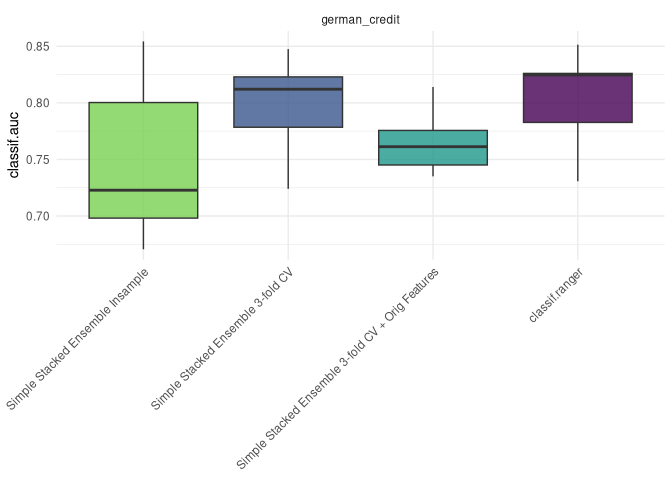

```r
# The task now also contains the original features of the task passed through

ensemble_cv_pass = as_learner(level0 %>>% level1)
ensemble_cv_pass$id = "Simple Stacked Ensemble 3-fold CV + Orig Features"

bg = benchmark_grid(task, list(ensemble, ensemble_cv, ensemble_cv_pass, rf), resampling)
b = benchmark(bg)
autoplot(b, measure = msr("classif.auc"))
```

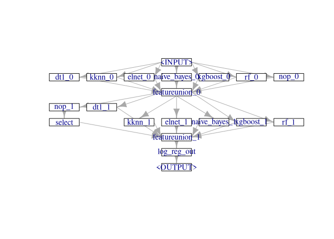

```r
# Usefulness of passing through the original features of the task usually strongly depends on the higher level learners
# If you have time, you may want to play around with the choice of the level 1 learner (or optimize it directly)

level0 = gunion(
  list(
    po("learner_cv", id = "dt1_0", learner = dt, resampling.method = "cv", resampling.folds = 3L),
    po("learner_cv", id = "kknn_0", learner = kknn, resampling.method = "cv", resampling.folds = 3L),
    po("learner_cv", id = "elnet_0", learner = elnet, resampling.method = "cv", resampling.folds = 3L),
    po("learner_cv", id = "naive_bayes_0", learner = naive_bayes, resampling.method = "cv", resampling.folds = 3L),
    po("learner_cv", id = "xgboost_0", learner = xgboost, resampling.method = "cv", resampling.folds = 3L),
    po("learner_cv", id = "rf_0", learner = rf, resampling.method = "cv", resampling.folds = 3L),
    po("nop", id = "nop_0")
  )
) %>>% po("featureunion", id = "featureunion_0")
level1 = gunion(
  list(
    po("learner_cv", id = "dt1_1", learner = dt, resampling.method = "cv", resampling.folds = 3L),
    po("learner_cv", id = "kknn_1", learner = kknn, resampling.method = "cv", resampling.folds = 3L),
    po("learner_cv", id = "elnet_1", learner = elnet, resampling.method = "cv", resampling.folds = 3L),
    po("learner_cv", id = "naive_bayes_1", learner = naive_bayes, resampling.method = "cv", resampling.folds = 3L),
    po("learner_cv", id = "xgboost_1", learner = xgboost, resampling.method = "cv", resampling.folds = 3L),
    po("learner_cv", id = "rf_1", learner = rf, resampling.method = "cv", resampling.folds = 3L),
    po("nop", id = "nop_1") %>>% po("select", selector = selector_name(task$feature_names))
  )
) %>>% po("featureunion", id = "featureunion_1")
level2 = lrn("classif.log_reg", id = "log_reg_out")
level2$predict_type = "prob"

ensemble_multilayer_cv_pass = as_learner(level0 %>>% level1 %>>% level2)
ensemble_multilayer_cv_pass$id = "Multilayer Stacked Ensemble 3-fold CV + Orig Features"
ensemble_multilayer_cv_pass$graph$plot()
```

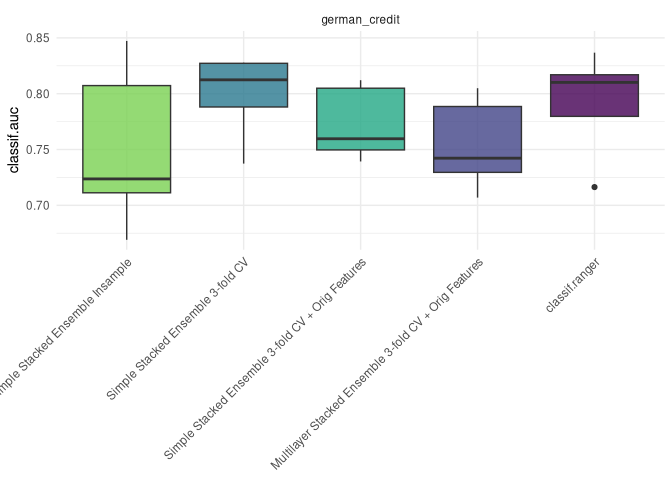

```r
bg = benchmark_grid(task, list(ensemble, ensemble_cv, ensemble_cv_pass, ensemble_multilayer_cv_pass, rf), resampling)
b = benchmark(bg)
autoplot(b, measure = msr("classif.auc"))
```

```r
# Sometimes beating a random forest baseline can be really difficult
```

## Exercise 2: Tuning a Stacked Ensemble

Construct a `TuningInstance` that terminates after 20 evaluations and inspect the search space. First, use the same resampling as used in the previous exercise and optimize ROC AUC via Bayesian Optimization. Use an initial design size of 10. Optimize the instance and inspect the results.

Finally, wrap everything in an `AutoTuner`. Use 3-fold CV as a resampling within the `AutoTuner` and optimize ROC AUC.

Benchmark this automatically tuned stacked ensemble against the untuned stacked ensemble and the random forest from above. This can take a while. Proper parallelization can be helpful.

**Hint 1:**

Defining a search space automatically is possible by setting hyperparameters to a tune token via `to_tune`. If you are not familiar with BO, the following might be helpful: https://mlr3book.mlr-org.com/chapters/chapter5/advanced_tuning_methods_and_black_box_optimization.html#sec-bayesian-optimization Regarding parallelization, you may want to look at: https://mlr3book.mlr-org.com/chapters/chapter10/advanced_technical_aspects_of_mlr3.html#sec-nested-resampling-parallelization

**Hint 2:**

```r
library(mlr3tuning)
library(mlr3mbo)

dt = lrn("classif.rpart", cp = ...)
dt$predict_type = "prob"
kknn = lrn(..., k = ...)
kknn$predict_type = "prob"
elnet = lrn(..., alpha = ..., s = ...)
elnet$predict_type = "prob"
elnet = as_learner(po(...) %>>% ...)
naive_bayes = lrn(...)
naive_bayes$predict_type = "prob"
naive_bayes = as_learner(po(...) %>>% ...)
xgboost = lrn(..., nrounds = ..., eta = ...)
xgboost = as_learner(po(...) %>>% ...)
xgboost$predict_type = "prob"
rf = lrn(..., num.trees = ..., mtry.ratio = ...)
rf$predict_type = "prob"

level0 = gunion(
  list(
    ...
  )
) %>>% po(...)
ensemble_tuned_cv = as_learner(level0 %>>% lrn(..., id = "log_reg_out", predict_type = "prob"))
ensemble_tuned_cv$id = "Simple Tuned Stacked Ensemble 3-fold CV + Orig Features"

instance = ti(
  ...
)
instance$search_space

tuner = tnr("mbo")
tuner$args = list(...)
tuner$optimize(...)

instance$archive$data

at = AutoTuner$new(
  ...
)

bg = benchmark_grid(..., list(...), ...)
b = benchmark(...)
autoplot(..., measure = ...)
```

### Solution:

**Click me:**

```r
library(mlr3tuning)
library(mlr3mbo)

dt = lrn("classif.rpart", cp = to_tune(p_dbl(lower = 1e-3, upper = 1, logscale = TRUE)))
dt$predict_type = "prob"
kknn = lrn("classif.kknn", k = to_tune(p_int(lower = 1L, upper = 10L)))
kknn$predict_type = "prob"
elnet = lrn("classif.glmnet", alpha = 0.5, s = to_tune(p_dbl(lower = 1e-5, upper = 1000, logscale = TRUE)))
elnet$predict_type = "prob"
elnet = as_learner(po("encodeimpact") %>>% elnet)
naive_bayes = lrn("classif.naive_bayes")
naive_bayes$predict_type = "prob"
naive_bayes = as_learner(po("encodeimpact") %>>% naive_bayes)
xgboost = lrn("classif.xgboost", nrounds = 100L, eta = to_tune(p_dbl(lower = 1e-5, upper = 1, logscale = TRUE)))
xgboost = as_learner(po("encodeimpact") %>>% xgboost)
xgboost$predict_type = "prob"
rf = lrn("classif.ranger", num.trees = 100L, mtry.ratio = to_tune(p_dbl(lower = 0.1, upper = 1)))
rf$predict_type = "prob"

level0 = gunion(
  list(
    po("learner_cv", learner = dt, resampling.method = "cv", resampling.folds = 3L),
    po("learner_cv", learner = kknn, resampling.method = "cv", resampling.folds = 3L),
    po("learner_cv", learner = elnet, resampling.method = "cv", resampling.folds = 3L),
    po("learner_cv", learner = naive_bayes, resampling.method = "cv", resampling.folds = 3L),
    po("learner_cv", learner = xgboost, resampling.method = "cv", resampling.folds = 3L),
    po("learner_cv", learner = rf, resampling.method = "cv", resampling.folds = 3L)
  )
) %>>% po("featureunion")
ensemble_tuned_cv = as_learner(level0 %>>% lrn("classif.log_reg", id = "log_reg_out", predict_type = "prob"))
ensemble_tuned_cv$id = "Simple Tuned Stacked Ensemble 3-fold CV + Orig Features"

instance = ti(
  task = task,
  learner = ensemble_tuned_cv,
  resampling = resampling,
  measures = msr("classif.auc"),
  terminator = trm("evals", n_evals = 20L)
)
instance$search_space
## <ParamSet>
##                                                  id    class      lower     upper nlevels
##                                              <char>   <char>      <num>     <num>   <num>
## 1:                                 classif.rpart.cp ParamDbl  -6.907755  0.000000     Inf
## 2:                                   classif.kknn.k ParamInt   1.000000 10.000000      10
## 3:     encodeimpact.classif.glmnet.classif.glmnet.s ParamDbl -11.512925  6.907755     Inf
## 4: encodeimpact.classif.xgboost.classif.xgboost.eta ParamDbl -11.512925  0.000000     Inf
## 5:                        classif.ranger.mtry.ratio ParamDbl   0.100000  1.000000     Inf
##                                                                                      default  value
##                                                                                       <list> <list>
## 1: <NoDefault>\n  Public:\n    clone: function (deep = FALSE) \n    initialize: function ()
## 2: <NoDefault>\n  Public:\n    clone: function (deep = FALSE) \n    initialize: function ()
## 3: <NoDefault>\n  Public:\n    clone: function (deep = FALSE) \n    initialize: function ()
## 4: <NoDefault>\n  Public:\n    clone: function (deep = FALSE) \n    initialize: function ()
## 5: <NoDefault>\n  Public:\n    clone: function (deep = FALSE) \n    initialize: function ()
## Trafo is set.
```